# ANGSD - HW Week 8

Tomer M. Yaron

3/9/2019

## 1 - Properties of RNAseq data and the relation to gene expression

1. **Gene length**: While performing RNA sequencing, we get reads from the same length, as we defined (usually 50-200 bp). Thus, the longer the gene, the higher number of counts we will get. However, if we are interested in the gene expression, we care about the number of *overlapping* reads from the same location (which will indicate that this location/gene was expressed multiple times), whereas two non-overlapping reads should be counted as one expressed transcript, since they could come from the same mRNA. Therefore, we need to normalize the gene counts to the length of the gene, in such a way that we will count the number of times the *gene* was expressed, without counting the actual reads. For that, we can use different normalization methods. The two most common methods are *Transcripts Per Million* (TPM) and *rlog*, which essentially normalize the raw number od reads count to the gene length and to the length of other genes in the genome, in such a way that the final number represents the expression of the gene itself. Another known method is RPKM/FPKM, which should not be used since it is not consistent across samples (and there is a rumor that you are being sent to hell and your papers never get accepted anymore…).
2. **Sequencing depth**: the deeper the sequencing will be, the more raw reads we will get, and therefore the more counts we will get. Similarly to the gene length correction, we will have to normalize the reads count. In that case, using the TPM and rlog methods, we will normalize for the total number of reads across all the genes, and therefore we will eloiminate the sequencing depth bias.
3. **Other highly expressed genes**: sometimes we are interested in genes which have a low expression level compare to other genes in the genome. In that case, the high expression of the other genes will reduce the resilution of the difference between our genes of interest. In that case, if we are interested in some particular genes, we can use only the reads mapped to them, and therefore our analysis will be more sensitive only for those genes.
4. **Expression of all genes in the sample**: when performing RNA sequencing, we are counting the reads from all the genes expressed in our samples. However, there are some genes which are much more expressed than other genes, and therefore can “shadow” the other genes and narrowing the range of other transcripts counts, which eventually does not allow us to perform an informative analysis of those transcripts’ expression. One of such example is ribocomal-RNA (rRNA), which is significantly higher expressed than other genes in the genome. The adjustment for dealing with that issue is not computational, but experimental. using different experimental libraries, we can enrich our samples for mRNA and thus to reduce the rRNA quantity, for getting better resolution for the mRNAs in the samples.

## 2 - DESeq2 S4 object

### a - Similarities and differences between *rlog* and *DESeqDataSetFromMatrix*

I was using rlog and DESeqDataSetFromMatrix online documentation.

### Similarities:

1. **Input data**: both methods get counts matrix, which is a non-negative integer matrix. To be noted that rlog can get also a DESeqDataSet object as an input.
2. **Normalization**: both of the methods takes raw counts matrix and normalize it (but by different normalization methods, see below), so differential expression analysis can be performed on the output, as well as exploratory analyses.

### Differences:

1. **Output format**: given that the input is a counts matrix, the output of rlog is simply a matrix with the normalized and transformed values, whereas the output of DESeqDataSetFromMatrix is DESeqDataSet object.
2. **Normalization method**: rlog normlization is meant to deal with the large synamic range of values as well as descrete values. Therefore, the out counts will be normalzed by their median, and transformed to a logaritmic scale. However, in DESeqDataSet, the normalization targets the sequencing depth issue, and therefore the raw counts are normalized by their size-factor (SF).
3. **Input parameters**: in rlog, the only required input is the counts matrix, so the normalization and transformation processes can be performed. In contrast, in DESeqDataSetFromMatrix, in addition to the counts matrix, also the *design* nput sould be provided, which is the condition which is the basis for the Differential Gene Expression analysis. The design parameter is a formula specifying the variables in the linear regression model, where the variables are being taken from the colData object, with is the meta-data for each sample.

### b - Extraction of the expression values

In rlog, the expression levels (which are the normalized reads count) is simply the results of the rlog() function.

In DESeqDataSetFromMatrix, we will use the function counts(dds.object, normalized = TRUE) for getting the SF-normalized expression levels.

### c - Adding a personal normalization matrix

For rlog object, since it i a simple matrix, we will use the function cbind(rlog.object, my_personal_normalization).

For DESeqDataSetFromMatrix, we need to convert the data into a dataframe first, so we will use mcols. The function will be: `new.dds <- cbind(mcols(norm.dds), my_personal_normalization)`.

## 3 - Exploratory analyses

```r
library(DESeq2)
```

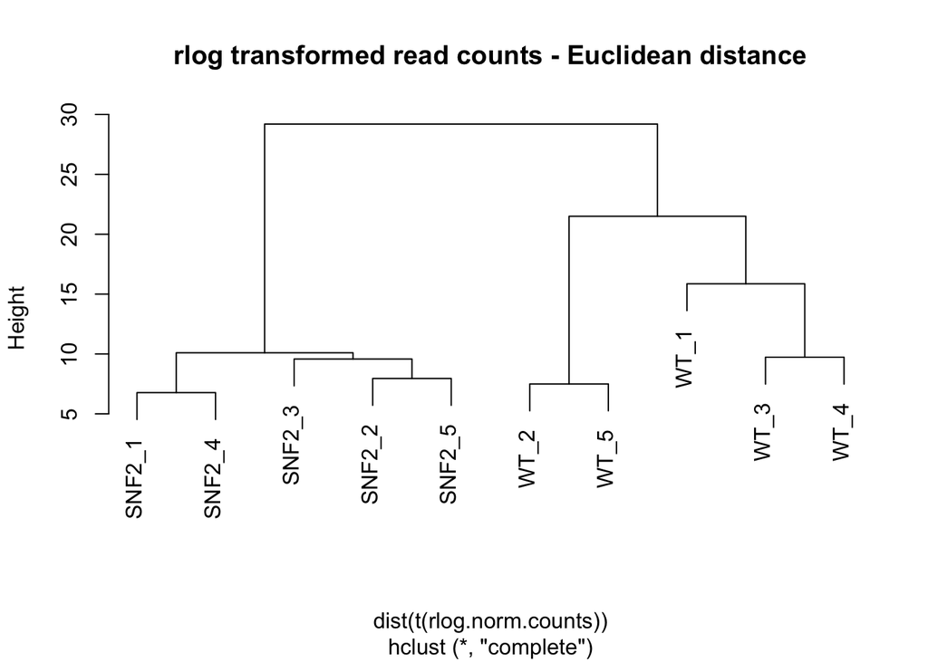

```r
library(ggplot2)
library(pcaExplorer)
library(magrittr)

counts.matrix <- read.table('featCounts_Gierlinski_genes.txt', header = TRUE)
row.names(counts.matrix) <- make.names(counts.matrix$Geneid)
counts.matrix <- counts.matrix[,-c(1:6)]
names(counts.matrix) <- c( paste("SNF2", c(1:5), sep = "_"), paste("WT", c(1:5), sep = "_"))
sample.info <- DataFrame(condition = gsub("_[0-9]+", "", names(counts.matrix)), row.names = names(counts.matrix) )


DESeq.ds <- DESeqDataSetFromMatrix(countData = counts.matrix, colData = sample.info, design = ~ condition)
DESeq.rlog <- rlog(DESeq.ds, blind = TRUE)
rlog.norm.counts <- assay(DESeq.rlog)

plot(hclust(dist(t(rlog.norm.counts))), labels = colnames(rlog.norm.counts), main = "rlog transformed read counts - Euclidean distance")
```

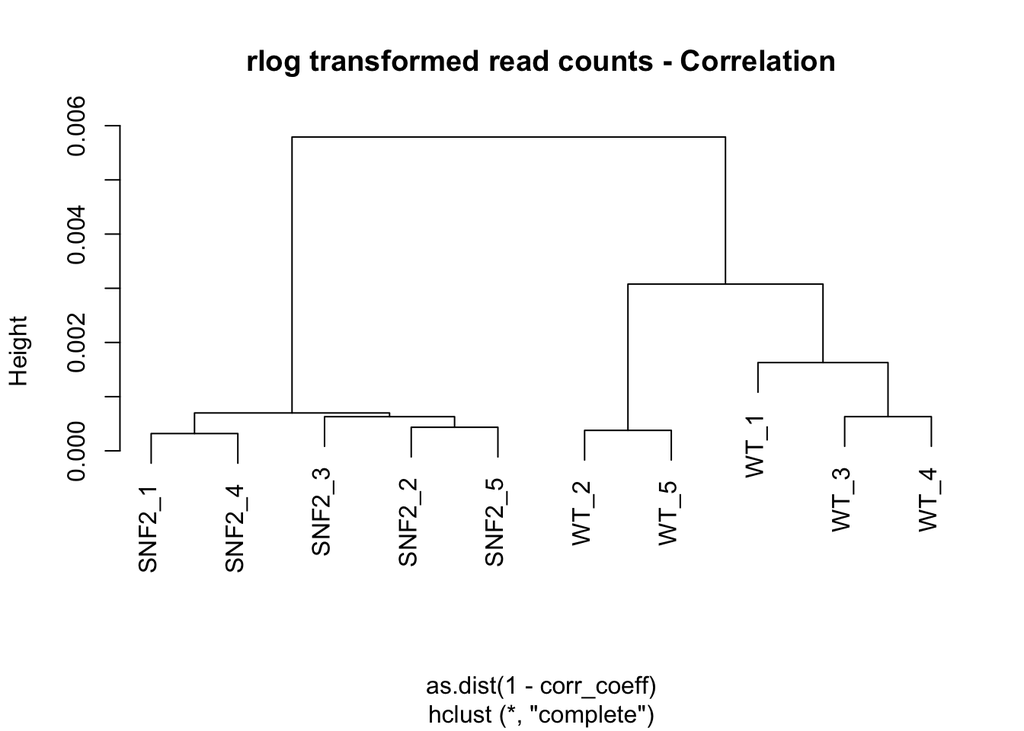

```r
corr_coeff <- cor(rlog.norm.counts, method = "pearson")
plot(hclust(as.dist(1 - corr_coeff)), labels = colnames(rlog.norm.counts), main = "rlog transformed read counts - Correlation")
```

We can see that either based on the Euclidian distance and based on the correlation between the columns, the WT samples are the most similar to each other and the SNF2 samples are the most similar to each other (based of the gene expression pattern).

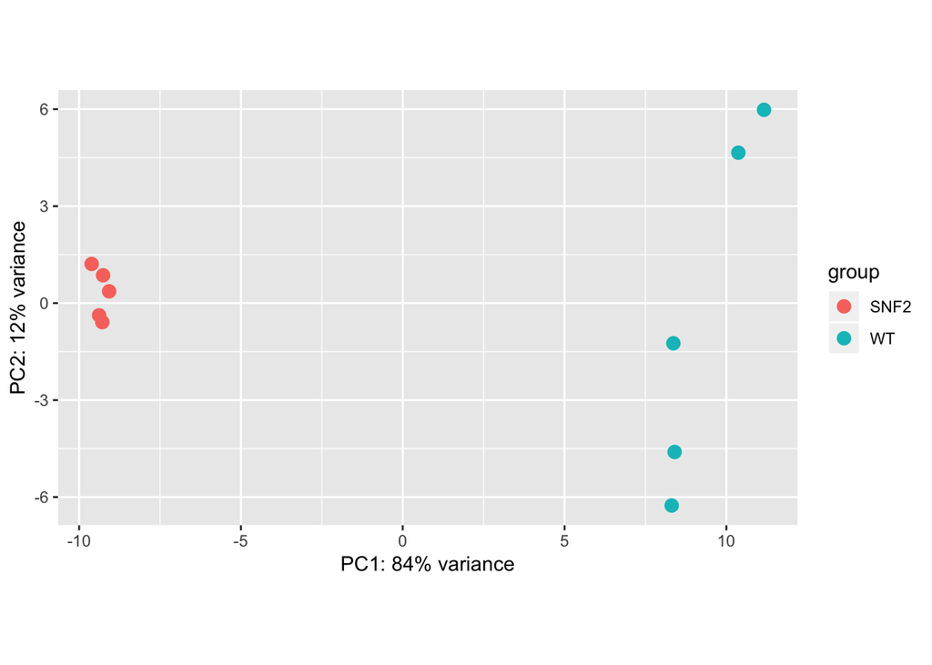

```r
rv <- rowVars(rlog.norm.counts)
top_variable <- order(rv, decreasing = TRUE)[seq_len(500)]
pca <- prcomp(t(assay(DESeq.rlog)[top_variable, ]))
plotPCA(DESeq.rlog)
```

Also in the PCA graph, we can see that the Principle Component #1 (which is the most significant PC) is similar the most among WT samples and among SNF2 samples, but quite different between T and SNF2. That means that the gene expression pattern of the WT is similar across samples, as well as of the SNF2 samples. However, whereas in the SNF2 there is almost no variability between the samples, in the WT there is variability between the samples.

The term *loadings* in PCA refers to the weight by which each standardized original variable should be multiplied to get the component score, which essentialy function as an indicator to the vraiance of the data points. Therefore, the Top-Loadings are genes which are vary the most across the data (and therefore explain the variance between samples), in probably are the relevant genes which their expression changed between WT and SNF2, where the Buttom Loadings are the opposite - the genes which their expression chagned the less.